# NLP project - Bartomeu Ramis

```r
library(keras)
library(dplyr)
library(ggplot2)
library(tm)
library(corpus)
library(wordcloud)
require(quanteda)
require(quanteda.textmodels)
library(quanteda.textplots)
require(caret)
```

# Definition of the problem and the data

This data set includes 23486 rows and 10 feature variables. Each row corresponds to a customer review, and includes the variables:

- Clothing ID: Integer Categorical variable that refers to the specific piece being reviewed.
- Age: Positive Integer variable of the reviewers age.
- Title: String variable for the title of the review.
- Review Text: String variable for the review body.
- Rating: Positive Ordinal Integer variable for the product score granted by the customer from 1 Worst, to 5 Best.
- Recommended IND: Binary variable stating where the customer recommends the product where 1 is recommended, 0 is not recommended.
- Positive Feedback Count: Positive Integer documenting the number of other customers who found this review positive.
- Division Name: Categorical name of the product high level division.
- Department Name: Categorical name of the product department name.
- Class Name: Categorical name of the product class name.

```r
set.seed(222)
data = read.csv("Womens Clothing E-Commerce Reviews.csv", header=TRUE)
head(data)
```

|  | X | Clothing.ID | Age | Title | Review.Text | Rating | Recommended.IND | Positive.Feedback.Count | Division.Name | Department.Name | Class.Name |
| --- | --- | --- | --- | --- | --- | --- | --- | --- | --- | --- | --- |
| 1 | 0 | 767 | 33 |  | Absolutely wonderful - silky and sexy and comfortable | 4 | 1 | 0 | Initmates | Intimate | Intimates |
| 2 | 1 | 1080 | 34 |  | Love this dress! it's sooo pretty. i happened to find it in a store, and i'm glad i did bc i never would have ordered it online bc it's petite. i bought a petite and am 5'8". i love the length on me- … | 5 | 1 | 4 | General | Dresses | Dresses |
| 3 | 2 | 1077 | 60 | Some major design flaws | I had such high hopes for this dress and really wanted it to work for me. i initially ordered the petite small (my usual size) but i found this to be outrageously small. so small in fact that i could … | 3 | 0 | 0 | General | Dresses | Dresses |
| 4 | 3 | 1049 | 50 | My favorite buy! | I love, love, love this jumpsuit. it's fun, flirty, and fabulous! every time i wear it, i get nothing but great compliments! | 5 | 1 | 0 | General Petite | Bottoms | Pants |
| 5 | 4 | 847 | 47 | Flattering shirt | This shirt is very flattering to all due to the adjustable front tie. it is the perfect length to wear with leggings and it is sleeveless so it pairs well with any cardigan. love this shirt!!! | 5 | 1 | 6 | General | Tops | Blouses |
| 6 | 5 | 1080 | 49 | Not for the very petite | I love tracy reese dresses, but this one is not for the very petite. i am just under 5 feet tall and usually wear a 0p in this brand. this dress was very pretty out of the package but its a lot of dre… | 2 | 0 | 4 | General | Dresses | Dresses |

## Objetive

Our objective with this data set, is to create a NLP model, that using the review text from a customer, can predict if that costumer was satisfied or not with it’s purchase. In our case, we will use de Recommended value as an indicator of the happiness of the customer.

# Data clearing

So, first of all, lets drop those columns that we wont be needing.

- Clothing ID could be useful if we were interested in which clothes have better opinions, but in our case, we don’t really care.
- Age is another piece of information that, for our purpose, we don’t need.
- Rating would be extremely useful if we had not the recommend IND. However, we will keep it, just in case.
- Positive feedback can also be omitted, given the fact that represents the opinion of other customers on the review, and gives no insight into the review’s expressed opinions.
- And finally, Division Name, Department Name and Class name wont bring any useful information for our objectives.

Also, we will change the names of some columns to be more intuitive and usable

```r
data = subset(data, select=c(X, Title, Review.Text, Rating, Recommended.IND))
names(data)[names(data) == "X"] <- "id"
names(data)[names(data) == "Review.Text"] <- "Text"
names(data)[names(data) == "Recommended.IND"] <- "Recommend"
summary(data)
```

```
       id           Title               Text               Rating        Recommend
 Min.   :    0   Length:23486       Length:23486       Min.   :1.000   Min.   :0.0000
 1st Qu.: 5871   Class :character   Class :character   1st Qu.:4.000   1st Qu.:1.0000
 Median :11742   Mode  :character   Mode  :character   Median :5.000   Median :1.0000
 Mean   :11742                                         Mean   :4.196   Mean   :0.8224
 3rd Qu.:17614                                         3rd Qu.:5.000   3rd Qu.:1.0000
 Max.   :23485                                         Max.   :5.000   Max.   :1.0000
```

The title of the review has also some key words that will be quite helpful to determinate the “feelings” of the customer. So in order to simplify the learning process we will merge the titled and the review text in a new column named “all_text”, and we will drop the “title” and “text” from our data set to make it more lightweight.

```r
data$all_text <-paste(data$Title,data$Text, sep=" ")
data = subset(data, select=c(id, Rating, Recommend, all_text))
head(data)
```

|  | id | Rating | Recommend | all_text |
| --- | --- | --- | --- | --- |
| 1 | 0 | 4 | 1 | Absolutely wonderful - silky and sexy and comfortable |
| 2 | 1 | 5 | 1 | Love this dress! it's sooo pretty. i happened to find it in a store, and i'm glad i did bc i never would have ordered it online bc it's petite. i bought a petite and am 5'8". i love the length on me- … |
| 3 | 2 | 3 | 0 | Some major design flaws I had such high hopes for this dress and really wanted it to work for me. i initially ordered the petite small (my usual size) but i found this to be outrageously small. so sma… |
| 4 | 3 | 5 | 1 | My favorite buy! I love, love, love this jumpsuit. it's fun, flirty, and fabulous! every time i wear it, i get nothing but great compliments! |
| 5 | 4 | 5 | 1 | Flattering shirt This shirt is very flattering to all due to the adjustable front tie. it is the perfect length to wear with leggings and it is sleeveless so it pairs well with any cardigan. love this… |
| 6 | 5 | 2 | 0 | Not for the very petite I love tracy reese dresses, but this one is not for the very petite. i am just under 5 feet tall and usually wear a 0p in this brand. this dress was very pretty out of the pack… |

Now, let’s look for null values.

```r
summary(data)
```

```
       id            Rating        Recommend        all_text
 Min.   :    0   Min.   :1.000   Min.   :0.0000   Length:23486
 1st Qu.: 5871   1st Qu.:4.000   1st Qu.:1.0000   Class :character
 Median :11742   Median :5.000   Median :1.0000   Mode  :character
 Mean   :11742   Mean   :4.196   Mean   :0.8224
 3rd Qu.:17614   3rd Qu.:5.000   3rd Qu.:1.0000
 Max.   :23485   Max.   :5.000   Max.   :1.0000
```

```r
cat("number of na/nan values: ", sum(is.na(data)),"\n")
```

```
number of na/nan values:  0
```

```r
cat("number of na/nan values for 'all_text' column: ",sum(is.na(data$all_text)), "\n")
```

```
number of na/nan values for 'all_text' column:  0
```

```r
cat("number of na/nan values for 'recommend' column: ",sum(is.na(data$Recommend)), "\n")
```

```
number of na/nan values for 'recommend' column:  0
```

It seem that the data is already clean from missing values. Next let’s look for outliers or non valid values.

```r
cat("number of values bigger than 1 or smaller than 0 for Recommend: ", sum(data$Recommend > 1 | data$Recommend < 0), "\n")
```

```
number of values bigger than 1 or smaller than 0 for Recommend:  0
```

```r
cat("number of values smaller than 1 and bigger than 0 for Recommend: ",sum(data$Recommend < 1 & data$Recommend > 0), "\n")
```

```
number of values smaller than 1 and bigger than 0 for Recommend:  0
```

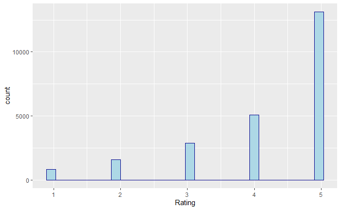

```r
ggplot(data, aes(x=Rating)) + geom_histogram(color="darkblue", fill="lightblue")
```

As we can see, all values seem to correspond to their intended meanings, with no outliers or invalid values (for example a Rating of -1). Also, with the histogram we are starting to visualise and explore the data, wich comes next.

# Exploratory analisis

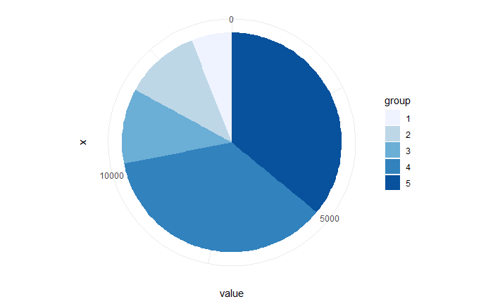

```r
df <- data.frame(
  group = c("1", "2", "3", "4", "5"),
  value = c(sum(data$Rating==1), sum(data$Rating==2), sum(data$Rating==2),sum(data$Rating==4),sum(data$Rating==4))
  )
 ggplot(df, aes(x="", y=value, fill=group)) + geom_bar(width = 1, stat = "identity")+ coord_polar("y", start=0)+ scale_fill_brewer(palette="Blues")+
  theme_minimal()
```

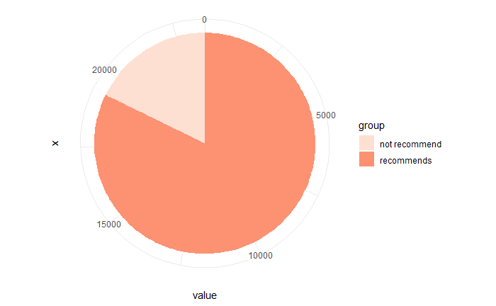

```r
df <- data.frame(
  group = c("recommends", "not recommend"),
  value = c(sum(data$Recommend==1), sum(data$Recommend==0))
  )
 ggplot(df, aes(x="", y=value, fill=group)) + geom_bar(width = 1, stat = "identity")+ coord_polar("y", start=0)+ scale_fill_brewer(palette="Reds")+
  theme_minimal()
```

Confirming our past hypothesis, clearly, more customers recommended the clothes in front of the less than a third of customers that did not. This will be a problem, because we would like balanced data, where we have a 50/50 split between happy and not so happy customers.

# Text preprocessing: normalization, removing non-letter characters, removing stopwords and stemming

Now that we have a general idea of the distribution of the reviews let’s normalize, remove “wierd” characters, and eliminate those words that bring no useful information (stopwords)

```r
summary(data$corpus <- corpus(data$all_text),10)
```

```
Corpus consisting of 23486 documents, showing 10 documents:

   Text Types Tokens Sentences
  text1     7      8         1
  text2    50     70         2
  text3    77    115         2
  text4    25     34         3
  text5    30     43         1
  text6    67    112         1
  text7    82    124         1
  text8    79    123         1
  text9    34     38         1
 text10    67     93         2
```

```r
data$tokens = tokens(data$corpus, remove_numbers = TRUE, remove_punct = TRUE, remove_separators = TRUE)
#data$dfm = dfm(data$tokens, remove = stopwords("english"), tolower=TRUE, stem = TRUE)
data$dfm = dfm(data$tokens, tolower=TRUE) %>% dfm_remove( stopwords_en) %>% dfm_wordstem()
summary(data$dfm)
```

```
   Length     Class      Mode
299117696       dfm        S4
```

With our Quanteda functions we can convert the text into a series of tokens, and in turn, those tokens into a Document-Feature Matrix, which will be the data used by the models. Our DFM, contains all words, with al characters converted to lowercase, without stopwords and stemmed. Stemming is the process of converting a word into it’s base form, facilitating the model learning process.

Let’s see graphically our DFM information, like which words are more common.

```r
topfeatures(data$dfm, 20) # 20 most frequent words
```

```
  dress    love     fit    size    look     top    wear    like   great   color perfect    just
  13812   13808   12100   10946    9576    9503    8201    7978    7901    7745    6163    5828
 fabric   order   small  beauti    cute    nice flatter  realli
   5170    5027    4981    4963    4589    4355    4174    4073
```

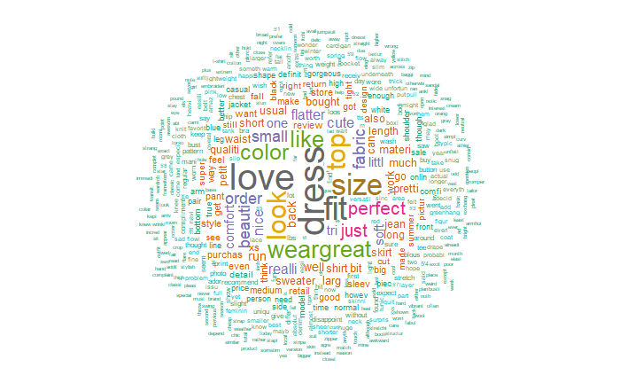

```r
textplot_wordcloud(data$dfm, random_order = FALSE,
                  rotation = .25,
                  color = RColorBrewer::brewer.pal(8, "Dark2"))
```

Intuitively, words like “dress”, “top” or “size” are very common due to the nature of our data. Other words like “love” or “perfect” indicate, again, that most of those reviews are positive; menwhile, words like “return”, indicating a desire to return the product, are much less common.